# IE562: Assignment 2

Use BFS to solve the 3M3C problem. The DFS solution is given below.

# Problem Description

3 missionaries and 3 cannibals are at the one side of a river

There is a boat on the river

[figure not shown]

## Objective:

Move all 3 missionaries and 3 cannibals to the another side of the river safely

## Constraints:

1. At most two people can be on the boat
2. Need at least one people on the boat to move from one side to another side
3. Whenever the number of canibals are larger than the number of missionaries (on the same side), the missionaries will be aten by canibals, and the task is failed

$S=[s_1,s_2,s_3,s_4,s_5]$

$s_1$: the number of missionaries on the left side of the river

$s_2$: the number of cannibals on the left side of the river

$s_3$: the location of the boat, if it is 1/0 then it is on the left/right side

$s_4$: the number of missionaries on the right side of the river

$s_5$: the number of cannibals on the right side of the river

## Initial State:

$ S_0=[3,3,1,0,0] $

## Goal State:

$ S^*=[0,0,0,3,3] $

# Action Space and State Transition:

$S=[s_1,s_2,s_3,s_4,s_5]$

1. if $s_3=1$:

   $0\le \delta_{s_i}\le \min\{2,s_i\},i=1,2$

   $\delta_{s_1}+\delta_{s_2}\le2$

   if $\delta_{s_1}+\delta_{s_2}\ge 1$:

   $S_{new}=[s_1-\delta_{s_{1}},s_2-\delta_{s_{2}},0,s_4+\delta_{s_{1}},s_5+\delta_{s_{2}}]$

   else:

   $S_{new}=S$
1. if $s_3=0$:

   $0\le \delta_{s_i}\le \min\{2,s_i\},i=4,5$

   $\delta_{s_4}+\delta_{s_5}\le2$

   if $\delta_{s_4}+\delta_{s_5}\ge 1$:

   $S_{new}=[s_1+\delta_{s_{4}},s_2+\delta_{s_{5}},1,s_4-\delta_{s_{4}},s_5-\delta_{s_{5}}]$

   else:

   $S_{new}=S$

## Stop

$S=[s_1,s_2,s_3,s_4,s_5]$

if $s_1=s_2=0$ and $s_4=s_5=3$ then stop (goal state)

```python
def obtain_actions(S):
    s3=S[2]
    actions=[]
    if s3==1:
        s1=S[0]
        s2=S[1]
        # delta1 in [0,s1]
        # delta2 in [0,s2]
        # delta1+delta2<=2
        for delta1 in range(s1+1):
            for delta2 in range(s2+1):
                if delta1+delta2<=2 and delta1+delta2>0:
                    actions.append([delta1,delta2])
    else:
        s4=S[3]
        s5=S[4]
        for delta4 in range(s4+1):
            for delta5 in range(s5+1):
                if delta4+delta5<=2 and delta4+delta5>0:
                    actions.append([delta4,delta5])
    return actions
```

```python
S=[3,3,1,0,0]
obtain_actions(S)
```

```
[[0, 1], [0, 2], [1, 0], [1, 1], [2, 0]]
```

```python
def failure(S):
    if (S[1]>S[0] and S[0]>0) or (S[4]>S[3] and S[3]>0):
        failed=True
    else:
        failed=False
    return failed

def next_state(S,action):
    s3=S[2]
    S_new=S[:]
    if s3==1:
        S_new[0]-=action[0]
        S_new[1]-=action[1]
        S_new[2]=0
        S_new[3]+=action[0]
        S_new[4]+=action[1]
    else:
        S_new[0]+=action[0]
        S_new[1]+=action[1]
        S_new[2]=1
        S_new[3]-=action[0]
        S_new[4]-=action[1]
    failed=failure(S_new)
    return S_new,failed
```

```python
actions=obtain_actions(S)
next_state(S,actions[0])
```

```
([3, 2, 0, 0, 1], False)
```

```python
next_state([0,1,0,3,2],[0,1])
```

```
([0, 2, 1, 3, 1], False)
```

```python
for action in actions:
    print(next_state(S,action))
```

```
([3, 2, 0, 0, 1], False)
([3, 1, 0, 0, 2], False)
([2, 3, 0, 1, 0], True)
([2, 2, 0, 1, 1], False)
([1, 3, 0, 2, 0], True)
```

```python
def fun(S,A):
    Sp=S[:]
    Sp[:2]=[S[s_idx]-A[a_idx] if S[2]==1 else A[a_idx] for a_idx,s_idx in enumerate([0,1])]
    Sp[-2:]=[S[s_idx]-A[a_idx] if S[2]==0 else A[a_idx] for a_idx,s_idx in enumerate([3,4])]
    Sp[2]=1-S[2]
    return Sp
```

# DFS

```python
def DFS(S,V,graph,goal_state=[0,0,0,3,3]):
    win=False
    if str(S) not in graph:
        graph[str(S)]=[]

    if S==goal_state:
        win=True
        print("Reached the goal state!")
        return V,win,graph

    print("Current State:",S)
    actions=obtain_actions(S)
    for action in actions:
        S_new,failed=next_state(S,action)
        print("New state:{}|failed:{}|visited:{}".format(S_new,failed,str(S_new) in V))
        if str(S_new) not in V:
            V.append(str(S_new))
            graph[str(S)].append(str(S_new))
            if not failed:
                print("    Exploring")
                V,win,graph=DFS(S_new,V,graph)
                if win:
                    break
    return V,win,graph
```

```python
S=[3,3,1,0,0]
V=[str(S)]
graph={}
V,win,graph=DFS(S,V,graph)
```

[output not shown]

```python
import networkx as nx
import matplotlib.pyplot as plt
```

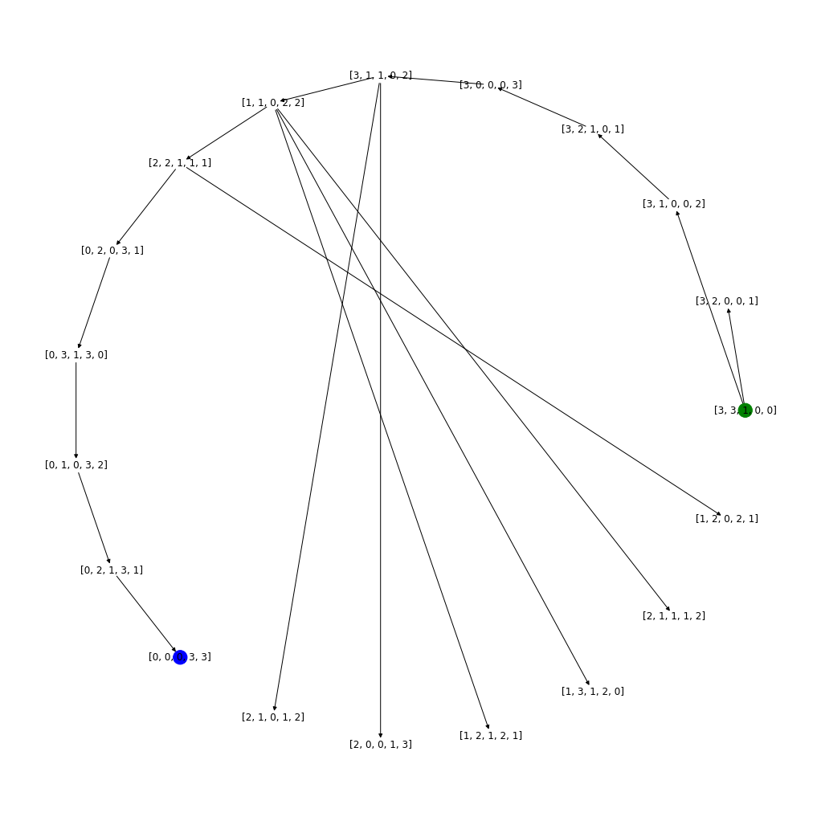

```python
plt.figure(figsize=(14,14))
g = nx.DiGraph(graph)
color_map = []
for node in g:
    if node == '[3, 3, 1, 0, 0]':
        color_map.append('green')
    elif node =='[0, 0, 0, 3, 3]':
        color_map.append('blue')
    else:
        color_map.append('white')
nx.draw(g,with_labels=True,node_color=color_map,\
        pos=nx.layout.circular_layout(g))
plt.show()
```

```python
nx.shortest_path(g,source=str([3,3,1,0,0]),target=str([0,0,0,3,3]))
```

```
['[3, 3, 1, 0, 0]',
 '[3, 1, 0, 0, 2]',
 '[3, 2, 1, 0, 1]',
 '[3, 0, 0, 0, 3]',
 '[3, 1, 1, 0, 2]',
 '[1, 1, 0, 2, 2]',
 '[2, 2, 1, 1, 1]',
 '[0, 2, 0, 3, 1]',
 '[0, 3, 1, 3, 0]',
 '[0, 1, 0, 3, 2]',
 '[0, 2, 1, 3, 1]',
 '[0, 0, 0, 3, 3]']
```

# Use BFS to solve the problem:

Requirements:

1. write a BFS function
2. visualize the the process of reaching goal state using networkx

```python
def BFS(S,visit,stack,graph,goal_state=[0,0,0,3,3]):
    win=False
    print("exploring {}".format(S))
    stack.remove(str(S))
    visit.append(str(S))
    if str(S)==str(goal_state):
        win=True
        return visit,stack,graph,win

    if str(S) not in graph:
        graph[str(S)]=[]

    actions=obtain_actions(S)
    for action in actions:
        S_new,failed=next_state(S,action)
        graph[str(S)].append(str(S_new))

        if str(S_new) not in visit:
            print("    new child of {}:{} (failed:{})".format(S,S_new,failed))
            if not failed:
                stack.append(str(S_new))
        else:
            print("    visited child {}".format(S_new))
    for Sp in stack:
        Sp=[int(s) for s in Sp[1:-1].replace(" ","").split(",")]
        if str(Sp) not in visit:
            visit,stack,graph,win=BFS(Sp,visit,stack,graph)
        if win:
            break
    return visit,stack,graph,win
```

```python
S=[3,3,1,0,0]
visit=[]
stack=[str(S)]
graph={}
visit,stack,graph,win=BFS(S,visit,stack,graph)
```

```
exploring [3, 3, 1, 0, 0]
    new child of [3, 3, 1, 0, 0]:[3, 2, 0, 0, 1] (failed:False)
    new child of [3, 3, 1, 0, 0]:[3, 1, 0, 0, 2] (failed:False)
    new child of [3, 3, 1, 0, 0]:[2, 3, 0, 1, 0] (failed:True)
    new child of [3, 3, 1, 0, 0]:[2, 2, 0, 1, 1] (failed:False)
    new child of [3, 3, 1, 0, 0]:[1, 3, 0, 2, 0] (failed:True)
exploring [3, 2, 0, 0, 1]
    visited child [3, 3, 1, 0, 0]
exploring [3, 1, 0, 0, 2]
    new child of [3, 1, 0, 0, 2]:[3, 2, 1, 0, 1] (failed:False)
    visited child [3, 3, 1, 0, 0]
exploring [2, 2, 0, 1, 1]
    new child of [2, 2, 0, 1, 1]:[2, 3, 1, 1, 0] (failed:True)
    new child of [2, 2, 0, 1, 1]:[3, 2, 1, 0, 1] (failed:False)
    visited child [3, 3, 1, 0, 0]
exploring [3, 2, 1, 0, 1]
    visited child [3, 1, 0, 0, 2]
    new child of [3, 2, 1, 0, 1]:[3, 0, 0, 0, 3] (failed:False)
    visited child [2, 2, 0, 1, 1]
    new child of [3, 2, 1, 0, 1]:[2, 1, 0, 1, 2] (failed:True)
    new child of [3, 2, 1, 0, 1]:[1, 2, 0, 2, 1] (failed:True)
exploring [3, 0, 0, 0, 3]
    new child of [3, 0, 0, 0, 3]:[3, 1, 1, 0, 2] (failed:False)
    visited child [3, 2, 1, 0, 1]
exploring [3, 1, 1, 0, 2]
    visited child [3, 0, 0, 0, 3]
    new child of [3, 1, 1, 0, 2]:[2, 1, 0, 1, 2] (failed:True)
    new child of [3, 1, 1, 0, 2]:[2, 0, 0, 1, 3] (failed:True)
    new child of [3, 1, 1, 0, 2]:[1, 1, 0, 2, 2] (failed:False)
exploring [1, 1, 0, 2, 2]
    new child of [1, 1, 0, 2, 2]:[1, 2, 1, 2, 1] (failed:True)
    new child of [1, 1, 0, 2, 2]:[1, 3, 1, 2, 0] (failed:True)
    new child of [1, 1, 0, 2, 2]:[2, 1, 1, 1, 2] (failed:True)
    new child of [1, 1, 0, 2, 2]:[2, 2, 1, 1, 1] (failed:False)
    visited child [3, 1, 1, 0, 2]
exploring [2, 2, 1, 1, 1]
    new child of [2, 2, 1, 1, 1]:[2, 1, 0, 1, 2] (failed:True)
    new child of [2, 2, 1, 1, 1]:[2, 0, 0, 1, 3] (failed:True)
    new child of [2, 2, 1, 1, 1]:[1, 2, 0, 2, 1] (failed:True)
    visited child [1, 1, 0, 2, 2]
```

[output cut: 8 more lines]

```
    new child of [0, 3, 1, 3, 0]:[0, 1, 0, 3, 2] (failed:False)
exploring [0, 1, 0, 3, 2]
    new child of [0, 1, 0, 3, 2]:[0, 2, 1, 3, 1] (failed:False)
    visited child [0, 3, 1, 3, 0]
    new child of [0, 1, 0, 3, 2]:[1, 1, 1, 2, 2] (failed:False)
    new child of [0, 1, 0, 3, 2]:[1, 2, 1, 2, 1] (failed:True)
    new child of [0, 1, 0, 3, 2]:[2, 1, 1, 1, 2] (failed:True)
exploring [0, 2, 1, 3, 1]
    visited child [0, 1, 0, 3, 2]
    new child of [0, 2, 1, 3, 1]:[0, 0, 0, 3, 3] (failed:False)
exploring [1, 1, 1, 2, 2]
    new child of [1, 1, 1, 2, 2]:[1, 0, 0, 2, 3] (failed:True)
    visited child [0, 1, 0, 3, 2]
    new child of [1, 1, 1, 2, 2]:[0, 0, 0, 3, 3] (failed:False)
exploring [0, 0, 0, 3, 3]
```

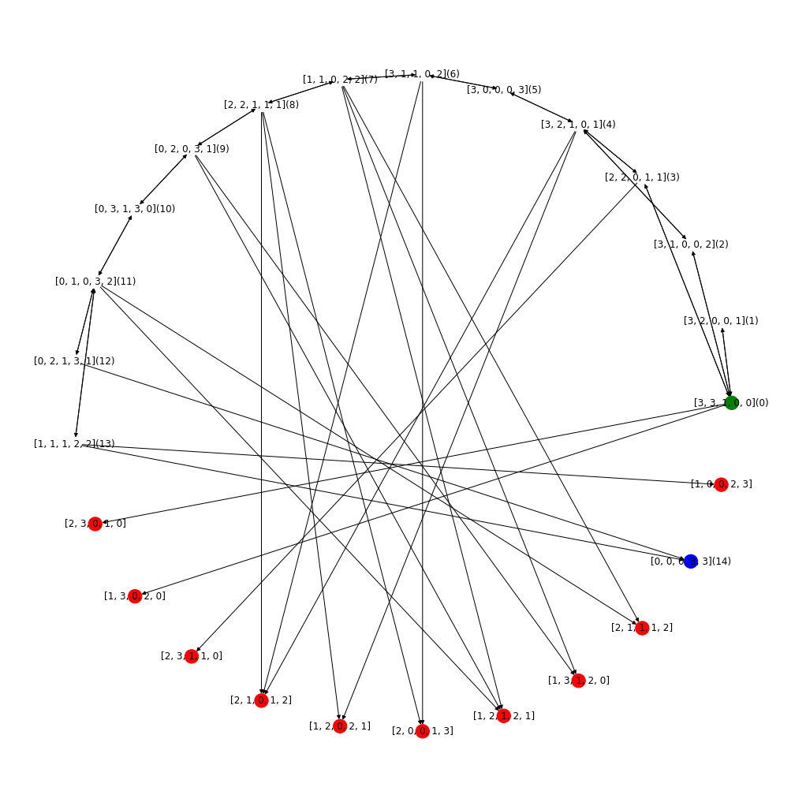

```python
plt.figure(figsize=(14,14))
g = nx.DiGraph(graph)
color_map = []
labels={}
for node in g:
    if node in visit:
        labels[node]="{}({})".format(node,visit.index(node))
    else:
        labels[node]=node
    if node == '[3, 3, 1, 0, 0]':
        color_map.append('green')
    elif node =='[0, 0, 0, 3, 3]':
        color_map.append('blue')
    elif failure([int(s) for s in node[1:-1].replace(" ","").split(",")])==True:
        color_map.append('red')
    else:
        color_map.append('white')
nx.draw(g,labels=labels,with_labels=True,node_color=color_map,\
        pos=nx.layout.circular_layout(g))
plt.show()
```

```python
nx.shortest_path(g,source=str([3,3,1,0,0]),target=str([0,0,0,3,3]))
```

```
['[3, 3, 1, 0, 0]',
 '[3, 1, 0, 0, 2]',
 '[3, 2, 1, 0, 1]',
 '[3, 0, 0, 0, 3]',
 '[3, 1, 1, 0, 2]',
 '[1, 1, 0, 2, 2]',
 '[2, 2, 1, 1, 1]',
 '[0, 2, 0, 3, 1]',
 '[0, 3, 1, 3, 0]',
 '[0, 1, 0, 3, 2]',
 '[0, 2, 1, 3, 1]',
 '[0, 0, 0, 3, 3]']
```

```python
def BFS(root,goal_state=[0,0,0,3,3]):
    visiteed, queue = [str([0,0,0,3,3])],collections.deque([root])

    graph1 = {}
    while queue:
        vertex = queue.popleft()


        if vertex==goal_state:
            print("goal reached sucessfully",vertex)
            return visiteed, queue,graph1
            break

        if str(vertex) not in visiteed:

            graph1[str(vertex)] = []
            try:

                for action in obtain_actions(vertex):
                    (a,b)=next_state(vertex,action)
                    if str(a) not in visiteed:
                        if b==False:
                            queue.append(a)
                            print("states in queue:",queue)
                            graph1[str(vertex)].append(str(a))
                        else:
                            visiteed.append(str(a))





            except:
                pass
            visiteed.append(str(vertex))
            print("visited states:",visiteed)

    return visiteed,queue,graph1
```

```python
a,b,g1=BFS([3,3,1,0,0])
print(a,b)
```

```
states in queue: deque([[3, 2, 0, 0, 1]])
states in queue: deque([[3, 2, 0, 0, 1], [3, 1, 0, 0, 2]])
states in queue: deque([[3, 2, 0, 0, 1], [3, 1, 0, 0, 2], [2, 2, 0, 1, 1]])
visited states: ['[0, 0, 0, 3, 3]', '[2, 3, 0, 1, 0]', '[1, 3, 0, 2, 0]', '[3, 3, 1, 0, 0]']
visited states: ['[0, 0, 0, 3, 3]', '[2, 3, 0, 1, 0]', '[1, 3, 0, 2, 0]', '[3, 3, 1, 0, 0]', '[3, 2, 0, 0, 1]']
states in queue: deque([[2, 2, 0, 1, 1], [3, 2, 1, 0, 1]])
visited states: ['[0, 0, 0, 3, 3]', '[2, 3, 0, 1, 0]', '[1, 3, 0, 2, 0]', '[3, 3, 1, 0, 0]', '[3, 2, 0, 0, 1]', '[3, 1, 0, 0, 2]']
states in queue: deque([[3, 2, 1, 0, 1], [3, 2, 1, 0, 1]])
visited states: ['[0, 0, 0, 3, 3]', '[2, 3, 0, 1, 0]', '[1, 3, 0, 2, 0]', '[3, 3, 1, 0, 0]', '[3, 2, 0, 0, 1]', '[3, 1, 0, 0, 2]', '[2, 3, 1, 1, 0]', '[2, 2, 0, 1, 1]']
states in queue: deque([[3, 2, 1, 0, 1], [3, 0, 0, 0, 3]])
visited states: ['[0, 0, 0, 3, 3]', '[2, 3, 0, 1, 0]', '[1, 3, 0, 2, 0]', '[3, 3, 1, 0, 0]', '[3, 2, 0, 0, 1]', '[3, 1, 0, 0, 2]', '[2, 3, 1, 1, 0]', '[2, 2, 0, 1, 1]', '[2, 1, 0, 1, 2]', '[1, 2, 0, 2, 1]', '[3, 2, 1, 0, 1]']
states in queue: deque([[3, 1, 1, 0, 2]])
visited states: ['[0, 0, 0, 3, 3]', '[2, 3, 0, 1, 0]', '[1, 3, 0, 2, 0]', '[3, 3, 1, 0, 0]', '[3, 2, 0, 0, 1]', '[3, 1, 0, 0, 2]', '[2, 3, 1, 1, 0]', '[2, 2, 0, 1, 1]', '[2, 1, 0, 1, 2]', '[1, 2, 0, 2, 1]', '[3, 2, 1, 0, 1]', '[3, 0, 0, 0, 3]']
states in queue: deque([[1, 1, 0, 2, 2]])
visited states: ['[0, 0, 0, 3, 3]', '[2, 3, 0, 1, 0]', '[1, 3, 0, 2, 0]', '[3, 3, 1, 0, 0]', '[3, 2, 0, 0, 1]', '[3, 1, 0, 0, 2]', '[2, 3, 1, 1, 0]', '[2, 2, 0, 1, 1]', '[2, 1, 0, 1, 2]', '[1, 2, 0, 2, 1]', '[3, 2, 1, 0, 1]', '[3, 0, 0, 0, 3]', '[2, 0, 0, 1, 3]', '[3, 1, 1, 0, 2]']
states in queue: deque([[2, 2, 1, 1, 1]])
visited states: ['[0, 0, 0, 3, 3]', '[2, 3, 0, 1, 0]', '[1, 3, 0, 2, 0]', '[3, 3, 1, 0, 0]', '[3, 2, 0, 0, 1]', '[3, 1, 0, 0, 2]', '[2, 3, 1, 1, 0]', '[2, 2, 0, 1, 1]', '[2, 1, 0, 1, 2]', '[1, 2, 0, 2, 1]', '[3, 2, 1, 0, 1]', '[3, 0, 0, 0, 3]', '[2, 0, 0, 1, 3]', '[3, 1, 1, 0, 2]', '[1, 2, 1, 2, 1]'…
states in queue: deque([[0, 2, 0, 3, 1]])
visited states: ['[0, 0, 0, 3, 3]', '[2, 3, 0, 1, 0]', '[1, 3, 0, 2, 0]', '[3, 3, 1, 0, 0]', '[3, 2, 0, 0, 1]', '[3, 1, 0, 0, 2]', '[2, 3, 1, 1, 0]', '[2, 2, 0, 1, 1]', '[2, 1, 0, 1, 2]', '[1, 2, 0, 2, 1]', '[3, 2, 1, 0, 1]', '[3, 0, 0, 0, 3]', '[2, 0, 0, 1, 3]', '[3, 1, 1, 0, 2]', '[1, 2, 1, 2, 1]'…
states in queue: deque([[0, 3, 1, 3, 0]])
visited states: ['[0, 0, 0, 3, 3]', '[2, 3, 0, 1, 0]', '[1, 3, 0, 2, 0]', '[3, 3, 1, 0, 0]', '[3, 2, 0, 0, 1]', '[3, 1, 0, 0, 2]', '[2, 3, 1, 1, 0]', '[2, 2, 0, 1, 1]', '[2, 1, 0, 1, 2]', '[1, 2, 0, 2, 1]', '[3, 2, 1, 0, 1]', '[3, 0, 0, 0, 3]', '[2, 0, 0, 1, 3]', '[3, 1, 1, 0, 2]', '[1, 2, 1, 2, 1]'…
states in queue: deque([[0, 1, 0, 3, 2]])
visited states: ['[0, 0, 0, 3, 3]', '[2, 3, 0, 1, 0]', '[1, 3, 0, 2, 0]', '[3, 3, 1, 0, 0]', '[3, 2, 0, 0, 1]', '[3, 1, 0, 0, 2]', '[2, 3, 1, 1, 0]', '[2, 2, 0, 1, 1]', '[2, 1, 0, 1, 2]', '[1, 2, 0, 2, 1]', '[3, 2, 1, 0, 1]', '[3, 0, 0, 0, 3]', '[2, 0, 0, 1, 3]', '[3, 1, 1, 0, 2]', '[1, 2, 1, 2, 1]'…
states in queue: deque([[0, 2, 1, 3, 1]])
states in queue: deque([[0, 2, 1, 3, 1], [1, 1, 1, 2, 2]])
visited states: ['[0, 0, 0, 3, 3]', '[2, 3, 0, 1, 0]', '[1, 3, 0, 2, 0]', '[3, 3, 1, 0, 0]', '[3, 2, 0, 0, 1]', '[3, 1, 0, 0, 2]', '[2, 3, 1, 1, 0]', '[2, 2, 0, 1, 1]', '[2, 1, 0, 1, 2]', '[1, 2, 0, 2, 1]', '[3, 2, 1, 0, 1]', '[3, 0, 0, 0, 3]', '[2, 0, 0, 1, 3]', '[3, 1, 1, 0, 2]', '[1, 2, 1, 2, 1]'…
visited states: ['[0, 0, 0, 3, 3]', '[2, 3, 0, 1, 0]', '[1, 3, 0, 2, 0]', '[3, 3, 1, 0, 0]', '[3, 2, 0, 0, 1]', '[3, 1, 0, 0, 2]', '[2, 3, 1, 1, 0]', '[2, 2, 0, 1, 1]', '[2, 1, 0, 1, 2]', '[1, 2, 0, 2, 1]', '[3, 2, 1, 0, 1]', '[3, 0, 0, 0, 3]', '[2, 0, 0, 1, 3]', '[3, 1, 1, 0, 2]', '[1, 2, 1, 2, 1]'…
visited states: ['[0, 0, 0, 3, 3]', '[2, 3, 0, 1, 0]', '[1, 3, 0, 2, 0]', '[3, 3, 1, 0, 0]', '[3, 2, 0, 0, 1]', '[3, 1, 0, 0, 2]', '[2, 3, 1, 1, 0]', '[2, 2, 0, 1, 1]', '[2, 1, 0, 1, 2]', '[1, 2, 0, 2, 1]', '[3, 2, 1, 0, 1]', '[3, 0, 0, 0, 3]', '[2, 0, 0, 1, 3]', '[3, 1, 1, 0, 2]', '[1, 2, 1, 2, 1]'…
['[0, 0, 0, 3, 3]', '[2, 3, 0, 1, 0]', '[1, 3, 0, 2, 0]', '[3, 3, 1, 0, 0]', '[3, 2, 0, 0, 1]', '[3, 1, 0, 0, 2]', '[2, 3, 1, 1, 0]', '[2, 2, 0, 1, 1]', '[2, 1, 0, 1, 2]', '[1, 2, 0, 2, 1]', '[3, 2, 1, 0, 1]', '[3, 0, 0, 0, 3]', '[2, 0, 0, 1, 3]', '[3, 1, 1, 0, 2]', '[1, 2, 1, 2, 1]', '[1, 3, 1, 2, …
```

```python
visit=a[:]
graph=g1
```

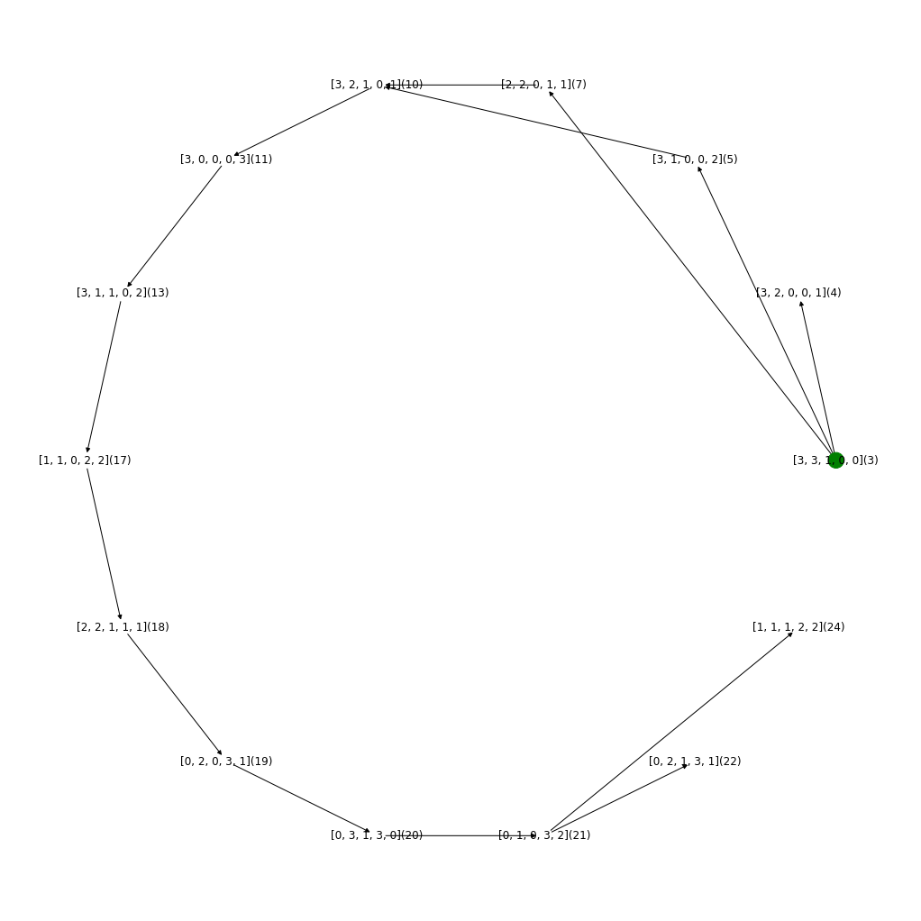

```python
plt.figure(figsize=(14,14))
g = nx.DiGraph(graph)
color_map = []
labels={}
for node in g:
    if node in visit:
        labels[node]="{}({})".format(node,visit.index(node))
    else:
        labels[node]=node
    if node == '[3, 3, 1, 0, 0]':
        color_map.append('green')
    elif node =='[0, 0, 0, 3, 3]':
        color_map.append('blue')
    elif failure([int(s) for s in node[1:-1].replace(" ","").split(",")])==True:
        color_map.append('red')
    else:
        color_map.append('white')
nx.draw(g,labels=labels,with_labels=True,node_color=color_map,\
        pos=nx.layout.circular_layout(g))
plt.show()
```